# 06.Example 2

Modified

Su 2026-09-13 19:44

## Given:

A major objective in advancing gas turbine engine technologies is to increase the temperature limit associated with operation of the gas turbine blades. This limit determines the permissible turbine gas inlet temperature, which, in turn, strongly influences overall system performance. In addition to fabricating turbine blades from special, high-temperature, high-strength superalloys, it is common to use internal cooling by machining flow channels within the blades and routing air through the channels. We wish to assess the effect of such a scheme by approximating the blade as a rectangular solid in which rectangular channels are machined. The blade, which has a thermal conductivity of $k=25\ \frac{\mathrm{W}}{\left(\mathrm{K} \cdot \mathrm{m}\right)}$, is $6\ \mathrm{mm}$ thick, and each channel has a $2\ \mathrm{mm} \times 6\ \mathrm{mm}$ rectangular cross section, with a $4\ \mathrm{mm}$ spacing between adjoining channels.

Figure 1: Blade Cross-Section

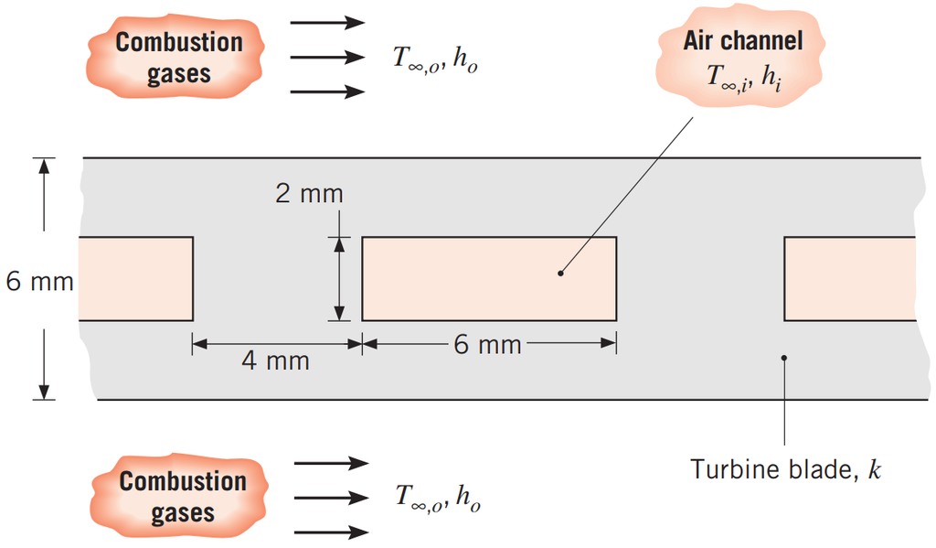

## Required:

Under operating conditions for which $h_o = 1000\ \frac{\mathrm{W}}{\left(\mathrm{K} \cdot \mathrm{m}^{2}\right)}$, $T_{\infty, o} = 1700\ \mathrm{K}$, $h_i = 200\ \frac{\mathrm{W}}{\left(\mathrm{K} \cdot \mathrm{m}^{2}\right)}$, and $T_{\infty, i} = 400\ \mathrm{K}$, determine the temperature field in the turbine blade. At what location is the temperature a maximum?

## Solution:

Start first by defining all of the given values.

$$k = 25\ \frac{\mathrm{W}}{\left(\mathrm{K} \cdot \mathrm{m}\right)}$$
$$t = 6\ \mathrm{mm}$$
$$H = 2\ \mathrm{mm}$$
$$W = 6\ \mathrm{mm}$$
$$S = 4\ \mathrm{mm}$$
$$h_o = 1000\ \frac{\mathrm{W}}{\left(\mathrm{K} \cdot \mathrm{m}^{2}\right)}$$
$$T_{\infty,o} = 1700\ \mathrm{K}$$
$$h_i = 200\ \frac{\mathrm{W}}{\left(\mathrm{K} \cdot \mathrm{m}^{2}\right)}$$
$$T_{\infty,i} = 400\ \mathrm{K}$$

To begin the analysis, the turbine blade body needs to be discretized. Recognizing the symmetry in the pattern of channels in the turbine body blade, the turbine body blade may be discretized using $\Delta x = \Delta y = 1 mm$ elements as shown below.

Figure 2: Discretized System

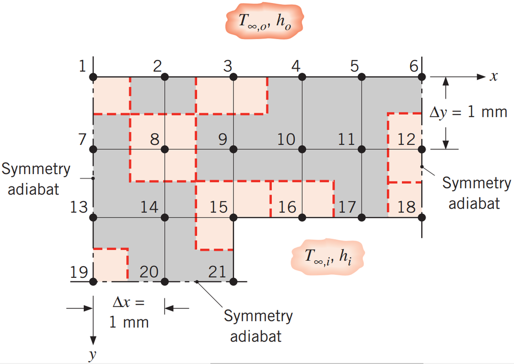

Analyzing node 1, it may then be seen that the heat flows are
$$q_1 = 0$$

$$q_2 = k \left( \frac{\Delta x}{2} \cdot 1 \right) \frac{T_7 - T_1}{\Delta y}$$

$$q_3 = k \left( \frac{\Delta y}{2} \cdot 1 \right) \frac{T_2 - T_1}{\Delta x}$$

$$q_4 = h_o \left( \frac{\Delta x}{2} \cdot 1 \right) \left( T_{\infty,o} - T_1 \right)$$

Combining these expression together for the energy balance yields
$$k \left( \frac{\Delta x}{2} \cdot 1 \right) \frac{T_7 - T_1}{\Delta y} + k \left( \frac{\Delta y}{2} \cdot 1 \right) \frac{T_2 - T_1}{\Delta x} + h_o \left( \frac{\Delta x}{2} \cdot 1 \right) \left( T_{\infty,o} - T_1 \right) = 0$$

Simplifying shows

Node 1: $T_2 + T_7 - \left(2 + \frac{h_o \Delta x}{k} \right) T_1 = -\frac{h_o \Delta x}{k} T_{\infty,o}$

It may be seen that nodes 6, 18, and 21 are comparable geometry so a similar approach and expression may be used. These are shown below.

Node 6: $T_5 + T_{12} - \left(2 + \frac{h_o \Delta x}{k} \right) T_6 = -\frac{h_o \Delta x}{k} T_{\infty,o}$

Node 18: $T_{17} + T_{12} - \left(2 + \frac{h_i \Delta x}{k} \right) T_{18} = -\frac{h_i \Delta x}{k} T_{\infty,i}$

Node 21: $T_{15} + T_{20} - \left(2 + \frac{h_i \Delta x}{k} \right) T_{21} = -\frac{h_i \Delta x}{k} T_{\infty,i}$

Continuing through the nodes, shows that nodes 2 through 5, 16, and 17 correspond to case 3. Thus, they are

Node 2: $T_1 + T_3 + 2T_8 - 2 \left( 2 + \frac{h_o \Delta x}{k} \right) T_2 = - 2 \frac{ h_o \Delta x}{k} T_{\infty,o}$

Node 3: $T_2 + T_4 + 2T_9 - 2 \left( 2 + \frac{h_o \Delta x}{k} \right) T_3 = - 2 \frac{ h_o \Delta x}{k} T_{\infty,o}$

Node 4: $T_3 + T_5 + 2T_{10} - 2 \left( 2 + \frac{h_o \Delta x}{k} \right) T_4 = - 2 \frac{ h_o \Delta x}{k} T_{\infty,o}$

Node 5: $T_4 + T_6 + 2T_{11} - 2 \left( 2 + \frac{h_o \Delta x}{k} \right) T_5 = - 2 \frac{ h_o \Delta x}{k} T_{\infty,o}$

Node 16: $T_{15} + T_{17} + 2T_{10} - 2 \left( 2 + \frac{h_i \Delta x}{k} \right) T_{16} = - 2 \frac{ h_i \Delta x}{k} T_{\infty,i}$

Node 17: $T_{16} + T_{18} + 2T_{11} - 2 \left( 2 + \frac{h_i \Delta x}{k} \right) T_{17} = - 2 \frac{ h_i \Delta x}{k} T_{\infty,i}$

Continuing through the nodes, shows that nodes 7, 12, 13, and 20 are a case 3 with adiabatic conditions. Thus, they are

Node 7: $T_{1} + 2T_{8} + T_{13} - 4 T_{7} = 0$

Node 12: $T_{6} + 2T_{11} + T_{18} - 4 T_{12} = 0$

Node 13: $T_{7} + 2T_{14} + T_{19} - 4 T_{13} = 0$

Node 20: $T_{19} + 2T_{14} + T_{21} - 4 T_{20} = 0$

Continuing through the nodes, shows that nodes 8 through 11 and 14 are case 1. Thus, they are

Node 8: $T_2 + T_7 + T_9 + T_{14} - 4T_8 = 0$

Node 9: $T_3 + T_8 + T_{10} + T_{15} - 4T_9 = 0$

Node 10: $T_4 + T_9 + T_{11} + T_{16} - 4T_{10} = 0$

Node 11: $T_5 + T_{10} + T_{12} + T_{17} - 4T_{11} = 0$

Node 14: $T_8 + T_{13} + T_{15} + T_{20} - 4T_{14} = 0$

Continuing through the nodes, shows that node 15 is case 2. Thus, it is

Node 15: $2T_9 + 2T_{14} + T_{16} + T_{21} - 2 \left( 3 + \frac{h_i \Delta x}{k} \right) T_{15} = - 2 \frac{h_i \Delta x}{k} T_{\infty,i}$

Lastly, it may be seen that node 19 is case 4 with adiabatic conditions. Thus, it is

Node 19: $T_{13} + T_{20} - 2 T_{19} = 0$

Now that the governing equations have all been stated, they must be gathered into the matrix form. It is sometimes helpful to recognize recurring terms and define them as simplier variables. The terms that commonly occur are shown below.

$$a = 2 + \frac{h_o \Delta x}{k} = 2.04$$

$$b = 2 ( 2 + \frac{h_o \Delta x}{k}) = 4.08$$

$$c = 2 ( 3 + \frac{h_i \Delta x}{k}) = 6.016$$

$$d = 2 ( 2 + \frac{h_i \Delta x}{k} ) = 4.016$$

$$e = 2 + \frac{h_i \Delta x}{k} = 2.008$$

$$f = \frac{h_o \Delta x}{k} T_{\infty,o} = 68.0\ \mathrm{K}$$

$$g = \frac{h_i \Delta x}{k} T_{\infty,i} = 3.2\ \mathrm{K}$$

Now the matrix $A$ may be assemblied. The matrix $A$ is constructed using a list of lists in Python and it then is converted into a proper matrix using NumPy’s array datatype. This process is shown below.

```python
import numpy as np

A = [[-a, 1, 0, 0, 0, 0, 1, 0, 0, 0, 0, 0, 0, 0, 0, 0, 0, 0, 0, 0, 0],
     [1, -b, 1, 0, 0, 0, 0, 2, 0, 0, 0, 0, 0, 0, 0, 0, 0, 0, 0, 0, 0],
     [0, 1, -b, 1, 0, 0, 0, 0, 2, 0, 0, 0, 0, 0, 0, 0, 0, 0, 0, 0, 0],
     [0, 0, 1, -b, 1, 0, 0, 0, 0, 2, 0, 0, 0, 0, 0, 0, 0, 0, 0, 0, 0],
     [0, 0, 0, 1, -b, 1, 0, 0, 0, 0, 2, 0, 0, 0, 0, 0, 0, 0, 0, 0, 0],
     [0, 0, 0, 0, 1, -a, 0, 0, 0, 0, 0, 1, 0, 0, 0, 0, 0, 0, 0, 0, 0],
     [1, 0, 0, 0, 0, 0, -4, 2, 0, 0, 0, 0, 1, 0, 0, 0, 0, 0, 0, 0, 0],
     [0, 1, 0, 0, 0, 0, 1, -4, 1, 0, 0, 0, 0, 1, 0, 0, 0, 0, 0, 0, 0],
     [0, 0, 1, 0, 0, 0, 0, 1, -4, 1, 0, 0, 0, 0, 1, 0, 0, 0, 0, 0, 0],
     [0, 0, 0, 1, 0, 0, 0, 0, 1, -4, 1, 0, 0, 0, 0, 1, 0, 0, 0, 0, 0],
     [0, 0, 0, 0, 1, 0, 0, 0, 0, 1, -4, 1, 0, 0, 0, 0, 1, 0, 0, 0, 0],
     [0, 0, 0, 0, 0, 1, 0, 0, 0, 0, 2, -4, 0, 0, 0, 0, 0, 1, 0, 0, 0],
     [0, 0, 0, 0, 0, 0, 1, 0, 0, 0, 0, 0, -4, 2, 0, 0, 0, 0, 1, 0, 0],
     [0, 0, 0, 0, 0, 0, 0, 1, 0, 0, 0, 0, 1, -4, 1, 0, 0, 0, 0, 1, 0],
     [0, 0, 0, 0, 0, 0, 0, 0, 2, 0, 0, 0, 0, 2, -c, 1, 0, 0, 0, 0, 1],
     [0, 0, 0, 0, 0, 0, 0, 0, 0, 2, 0, 0, 0, 0, 1, -d, 1, 0, 0, 0, 0],
     [0, 0, 0, 0, 0, 0, 0, 0, 0, 0, 2, 0, 0, 0, 0, 1, -d, 1, 0, 0, 0],
     [0, 0, 0, 0, 0, 0, 0, 0, 0, 0, 0, 1, 0, 0, 0, 0, 1, -e, 0, 0, 0],
     [0, 0, 0, 0, 0, 0, 0, 0, 0, 0, 0, 0, 1, 0, 0, 0, 0, 0, -2, 1, 0],
     [0, 0, 0, 0, 0, 0, 0, 0, 0, 0, 0, 0, 0, 2, 0, 0, 0, 0, 1, -4, 1],
     [0, 0, 0, 0, 0, 0, 0, 0, 0, 0, 0, 0, 0, 0, 1, 0, 0, 0, 0, 1, -e]]
A = np.array(A)
```

It should be noted that each row of the matrix $A$ corresponds to the derive expression for the nodes. That is to say, row 1 is the node 1 expression, row 2 is the node 2 expression, etc. A similar process may be done for vector $C$. This process is shown below.

```python
C = [-f, -2*f, -2*f, -2*f, -2*f, -f, 0, 0, 0, 0, 0, 0, 0, 0, -2*g, -2*g, -2*g, -g, 0, 0, -g]
C = np.array(C)
```

The temperatures of the nodes may now be found by the matrix equation below.

$$T = A^{-1} C$$

This operation is shown below in Python.

```python
T = np.matmul(np.linalg.inv(A), C) # answer to first part
print(T)
```

```
[1525.95413813 1525.27944565 1523.59609075 1521.93574674 1520.83066847
 1520.45069026 1519.66699612 1518.7949547  1516.52842892 1514.53554374
 1513.30134519 1512.88873965 1515.12393697 1513.70494809 1509.18712651
 1506.37665411 1504.9504289  1504.50157796 1513.41885557 1511.71377418
 1506.02634497]
```

The maximum value and it’s location may now be found. This is shown below.

```python
T = list(T)
T_max = max(T)
T_max_location = T.index(T_max) + 1

print('Max temperature:', round(T_max, 1))
print('Node with max temperature:', T_max_location) # answer to second part
```

```
Max temperature: 1526.0
Node with max temperature: 1
```